# Week 3

## Welcome to 2*2 Tables!

## First Table Year 1990

```r
gss1990 <- gss_get_yr(1990)
```

```
Fetching: https://gss.norc.org/documents/stata/1990_stata.zip
```

```r
select(gss1990, divorce, happy)
```

```
# A tibble: 1,372 × 2
   divorce     happy
   <dbl+lbl>   <dbl+lbl>
 1 NA(i) [iap] 2 [pretty happy]
 2 NA(i) [iap] 1 [very happy]
 3 NA(i) [iap] 2 [pretty happy]
 4 NA(i) [iap] 2 [pretty happy]
 5 NA(i) [iap] 2 [pretty happy]
 6     1 [yes] 2 [pretty happy]
 7 NA(i) [iap] 3 [not too happy]
 8     2 [no]  3 [not too happy]
 9     2 [no]  2 [pretty happy]
10     2 [no]  2 [pretty happy]
# ℹ 1,362 more rows
```

```r
a <- gss1990 |>
  select(divorce, happy) |>
  drop_na() |>
  mutate(vdivorce = if_else(divorce == 1,
                             "Divorced",
                             "Not divorced"),
         vhappy = if_else (happy == 1 | happy == 2, #where happy=3 means not too happy
                           "Happy",
                           "Not happy")) |>
  select(vdivorce, vhappy)
a
```

```
# A tibble: 888 × 2
   vdivorce     vhappy
   <chr>        <chr>
 1 Divorced     Happy
 2 Not divorced Not happy
 3 Not divorced Happy
 4 Not divorced Happy
 5 Not divorced Not happy
 6 Not divorced Happy
 7 Not divorced Happy
 8 Not divorced Happy
 9 Not divorced Happy
10 Not divorced Not happy
# ℹ 878 more rows
```

```r
Contingency_table1 <- a |>
  group_by(vdivorce, vhappy) |>
  tally() |>
  pivot_wider(names_from = vdivorce, values_from = n )
tt(Contingency_table1)
```

| vhappy | Divorced | Not divorced |
| --- | --- | --- |
| Happy | 173 | 655 |
| Not happy | 18 | 42 |

## 1990 Compute and Interpret

Marginal probability:

Being happy is 0.932, which means in total, 93.2% people are being happy.

```r
(173+655)/(173+655+18+42)
```

```
[1] 0.9324324
```

Being divorced is 0.215, which means in total, 21.5% people are divorced.

```r
(173+18)/(172+655+18+42)
```

```
[1] 0.2153326
```

Joint probability:

Being divorced and being happy is 0.195, which means among all people, 19.5% people are happy and divorced.

```r
173/(173+655+18+42)
```

```
[1] 0.1948198
```

Being unhappy and being not divorced is 0.047, which means among all people, 4.7% people are unhappy and not divorced.

```r
42/(173+655+18+42)
```

```
[1] 0.0472973
```

Conditional probability：

Being happy in the condition of being divorced is 0.906, which means among divorced people, 90.6% are happy.

```r
173/(173+18)
```

```
[1] 0.9057592
```

```r
173/(173+655)
```

```
[1] 0.2089372
```

## Second Table Year 2022

```r
gss2022 <- gss_get_yr(2022)
```

```
Fetching: https://gss.norc.org/documents/stata/2022_stata.zip
```

```r
b <- gss2022 |>
  select(divorce, happy) |>
  drop_na() |>
  mutate(vdivorce = if_else(divorce == 1,
                             "Divorced",
                             "Not divorced"),
         vhappy = if_else (happy == 1 | happy == 2,
                           "Happy",
                           "Not happy")) |>
  select(vdivorce, vhappy)
```

```r
Contingency_table2 <- b |>
  group_by(vdivorce, vhappy) |>
  tally() |>
  pivot_wider(names_from = vdivorce, values_from = n )
tt(Contingency_table2)
```

| vhappy | Divorced | Not divorced |
| --- | --- | --- |
| Happy | 424 | 1257 |
| Not happy | 101 | 204 |

## 2022 Compute and Interpret

Marginal probability:

Being happy is 0.846, which means in total, 84.6% people are happy.

```r
(424+1257)/(424+1257+101+204)
```

```
[1] 0.846425
```

Being divorced is 0.264, which means in total, 26.4% people are divorced.

```r
(424+101)/(424+1257+101+204)
```

```
[1] 0.2643505
```

Joint probability:

Being divorced and being happy is 0.213, which means among all people, 21.3% are divorced and happy.

```r
424/(424+1257+101+204)
```

```
[1] 0.2134945
```

```r
204/(424+1257+101+204)
```

```
[1] 0.102719
```

Conditional probability:

Being happy in the condition of being divorced is 0.808, which means among people who are divorced, 80.8% people are happy.

```r
424/(424+101)
```

```
[1] 0.807619
```

Being divorced in the condition of being happy is 0.252, which means among people who are happy, 25.2% people are divorced.

```r
424/(1257+424)
```

```
[1] 0.2522308
```

## Changes from 1990 to 2022

Being divorced in the condition of being happy

```r
conditional1990 <- a |> mutate(num_divorce = if_else(vdivorce == "Divorced",
                                                     1,0)) |>
  group_by(vhappy) |>
  summarize(conditional1990 = mean(num_divorce))
conditional1990
```

```
# A tibble: 2 × 2
  vhappy    conditional1990
  <chr>               <dbl>
1 Happy               0.209
2 Not happy           0.3
```

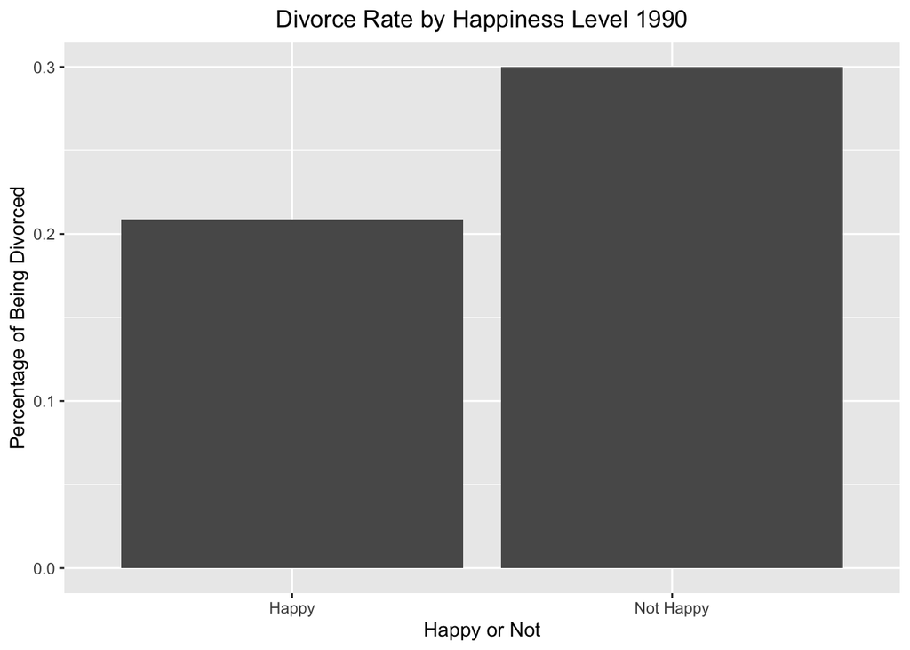

```r
ggplot(conditional1990,
       aes(x = factor(vhappy, labels = c("Happy",
                                         "Not Happy")),
           y = conditional1990
        )) +
  geom_col()+
  xlab("Happy or Not") +
  ylab("Percentage of Being Divorced") +
  ggtitle("Divorce Rate by Happiness Level 1990" )+
  theme(
    plot.title = element_text(hjust = 0.5)
  )
```

```r
conditional2022 <- b |> mutate(num_divorce = if_else(vdivorce == "Divorced",
                                  1, 0) ) |>
  group_by(vhappy) |>
  summarize(conditional2022 = mean(num_divorce))

conditional2022
```

```
# A tibble: 2 × 2
  vhappy    conditional2022
  <chr>               <dbl>
1 Happy               0.252
2 Not happy           0.331
```

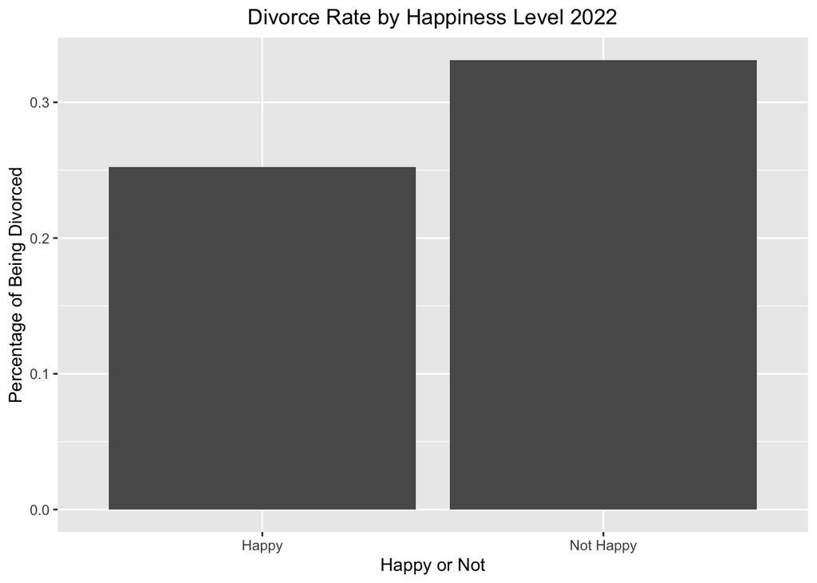

```r
ggplot(conditional2022,
       aes(
         x= factor(vhappy, labels = c("Happy",
                                      "Not Happy")),
         y= conditional2022
       )) +
  geom_col()+
  xlab("Happy or Not")+
  ylab("Percentage of Being Divorced")+
  ggtitle("Divorce Rate by Happiness Level 2022")+
  theme(
    plot.title = element_text(hjust = 0.5)
  )
```

In general, the percentage of people being divorced increased from 21.5% in 1990 to 26.4% in 2022. Among people are happy, the percentage of being divorced increased from 20.9% to 25.2%; Among people are not happy, the percentage of being divorced increased from 30.0% to 33.1%.